# Data Exploration Analysis

## The Data

We work with two dataframes of the following data:

- Crop historical data: **agr_df**
- Price series (corn): **corn_df**

## Crop data

First we will explore the crop data to identify different characteristics of agriculture in Mexico in the years **2003-2020**.

The data can be found in the official website of SIAP: http://infosiap.siap.gob.mx/gobmx/datosAbiertos.php

| year | id_state | state | id_district | district | id_cader | cader | id_municipality | municipality | id_cycle | cycle | id_type | type | id_unit | unit | id_crop | crop | sowed | harvested | damaged | volume | yield | price | production_value |
| --- | --- | --- | --- | --- | --- | --- | --- | --- | --- | --- | --- | --- | --- | --- | --- | --- | --- | --- | --- | --- | --- | --- | --- |
| 2003 | 1 | Aguascalientes | 1 | Aguascalientes | 1 | Aguascalientes | 1 | Aguascalientes | 1 | Otoño-Invierno | 1 | Riego | 200201 | Tonelada | 5490000 | Avena forrajera en verde | 1062 | 1062 | 0 | 28529 | 26.86 | 323.4 | 9226279 |
| 2003 | 1 | Aguascalientes | 1 | Aguascalientes | 1 | Aguascalientes | 1 | Aguascalientes | 1 | Otoño-Invierno | 1 | Riego | 200201 | Tonelada | 5900000 | Cebada forrajera en verde | 2 | 2 | 0 | 54 | 27 | 250.0 | 13500 |
| 2003 | 1 | Aguascalientes | 1 | Aguascalientes | 1 | Aguascalientes | 1 | Aguascalientes | 1 | Otoño-Invierno | 1 | Riego | 200201 | Tonelada | 5980000 | Centeno forrajero en verde | 17 | 17 | 0 | 1020 | 60 | 350.0 | 357000 |
| 2003 | 1 | Aguascalientes | 1 | Aguascalientes | 1 | Aguascalientes | 1 | Aguascalientes | 1 | Otoño-Invierno | 1 | Riego | 200201 | Tonelada | 9090000 | Triticale forrajero en verde | 24 | 24 | 0 | 720 | 30 | 400.0 | 288000 |
| 2003 | 1 | Aguascalientes | 1 | Aguascalientes | 1 | Aguascalientes | 1 | Aguascalientes | 1 | Otoño-Invierno | 1 | Riego | 200201 | Tonelada | 15050000 | Pastos y praderas | 415 | 415 | 0 | 25830 | 62.24 | 314.9 | 8133867 |
| 2003 | 1 | Aguascalientes | 1 | Aguascalientes | 1 | Aguascalientes | 1 | Aguascalientes | 2 | Primavera-Verano | 1 | Riego | 200201 | Tonelada | 5670000 | Brócoli | 72 | 72 | 0 | 864 | 12 | 4925.0 | 4255200 |

#### Top 10 states

The following plot shows the top 10 states (in 2020) with the most hectares sowed over the years. This includes all crops, all cycles and all types (modalities).

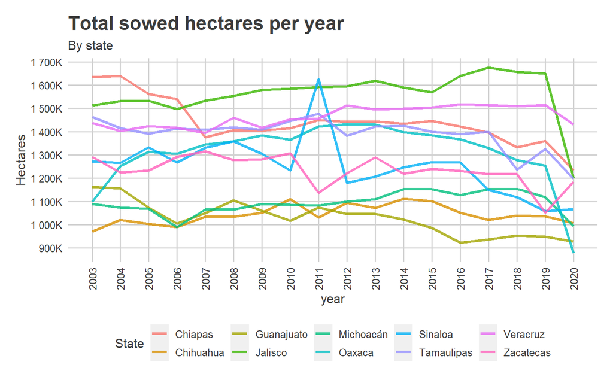

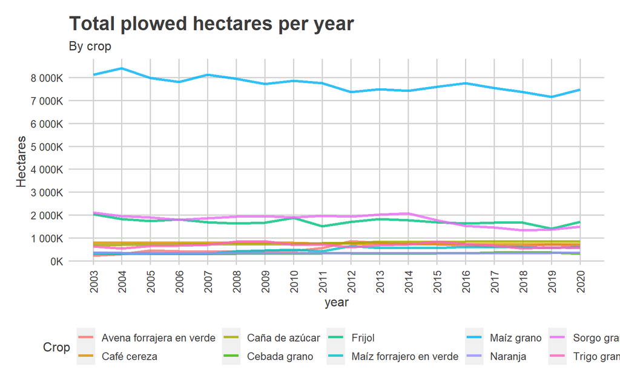

#### Top 4 crops per cycle

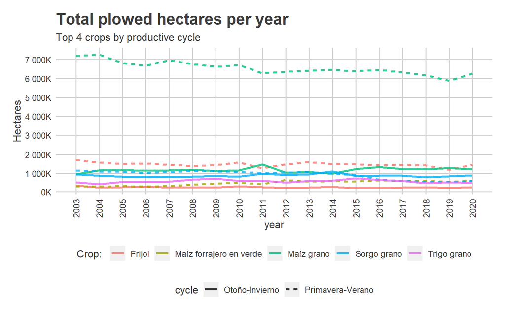

#### Top 5 states per cycle

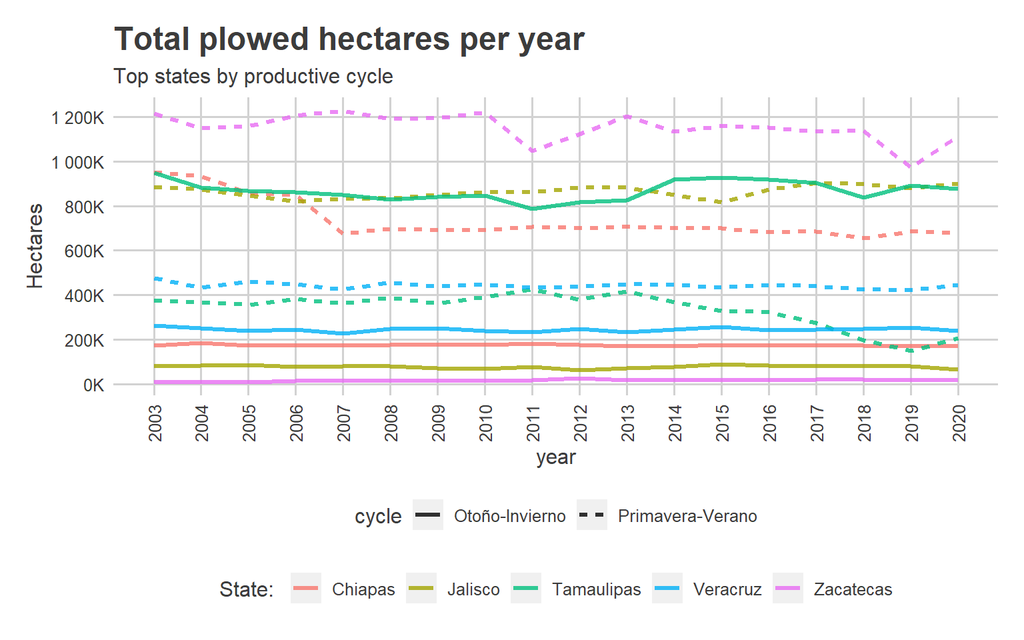

### Price vs Yield

Next we compare the yield and the price of corn for a specific district to visualize the relationship of these two series over time. Note that we show both the *original* and *detrended* series, the later will be used in all of the analysis.

#### Corn - Irrigation, Autumn-Winter, Guasave-Sinaloa

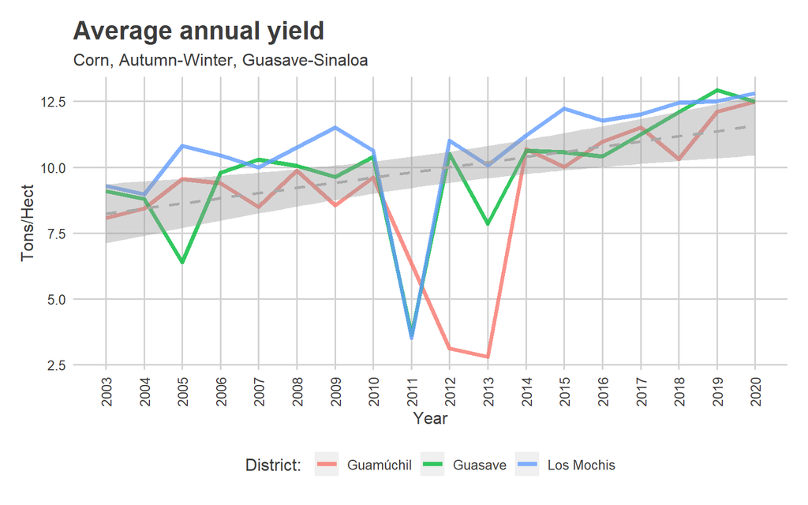

[figure not shown]

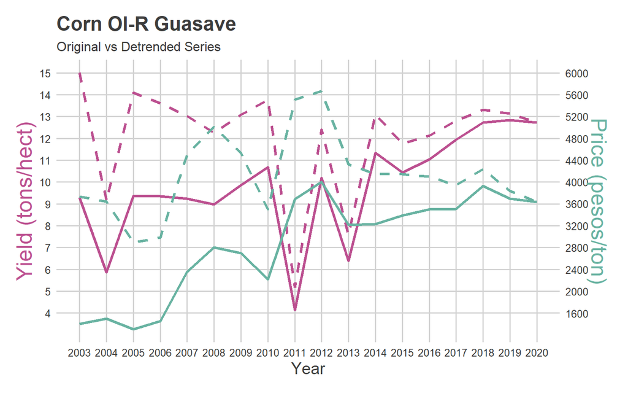

## Price Series

For the price series we used the continuous futures contracts from the Quandl API:

[Link to Quandl Continuous Futures](https://data.nasdaq.com/data/CHRIS-wiki-continuous-futures/documentation)

### Corn

Since corn is of main interest to us (most sowed crop) we next do some DEA on its series.

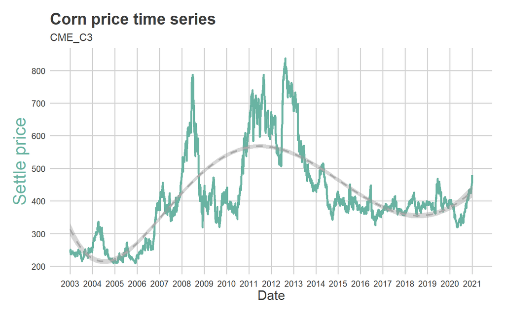